# Project - 2 Healthcare PGP

### Problem Statement

- NIDDK (National Institute of Diabetes and Digestive and Kidney Diseases) research creates knowledge about and treatments for the most chronic, costly, and consequential diseases.
- The dataset used in this project is originally from NIDDK. The objective is to predict whether or not a patient has diabetes, based on certain diagnostic measurements included in the dataset.
- Build a model to accurately predict whether the patients in the dataset have diabetes or not.

### Dataset Description

The datasets consists of several medical predictor variables and one target variable (Outcome). Predictor variables includes the number of pregnancies the patient has had, their BMI, insulin level, age, and more.

| Variables | Description |
| --- | --- |
| Pregnancies | Number of times pregnant |
| Glucose | Plasma glucose concentration in an oral glucose tolerance test |
| BloodPressure | Diastolic blood pressure (mm Hg) |
| SkinThickness | Triceps skinfold thickness (mm) |
| Insulin | Two hour serum insulin |
| BMI | Body Mass Index |
| DiabetesPedigreeFunction | Diabetes pedigree function |
| Age | Age in years |
| Outcome | Class variable (either 0 or 1). 268 of 768 values are 1, and the others are 0 |

### Project Task: Week 1

**Data Exploration:**

1. Perform descriptive analysis. Understand the variables and their corresponding values. On the columns below, a value of zero does not make sense and thus indicates missing value:

• Glucose

• BloodPressure

• SkinThickness

• Insulin

• BMI

1. Visually explore these variables using histograms. Treat the missing values accordingly.
2. There are integer and float data type variables in this dataset. Create a count (frequency) plot describing the data types and the count of variables.

Download the **datasets** from **[here](https://github.com/Simplilearn-Edu/Data-Science-Capstone-Projects)**.

# Code:

```python
# Importing pandas, Numpy, matplotlib and seaborn libararies
import pandas as pd
import numpy as np
import matplotlib.pyplot as plt
import seaborn as sns
%matplotlib inline
```

```python
# Reading the file Excel file from the pandas libaray
dataset=pd.read_csv('health care diabetes.csv')
```

```python
#Top 5 dataset
dataset.head(10)
```

|  | Pregnancies | Glucose | BloodPressure | SkinThickness | Insulin | BMI | DiabetesPedigreeFunction | Age | Outcome |
| --- | --- | --- | --- | --- | --- | --- | --- | --- | --- |
| 0 | 6 | 148 | 72 | 35 | 0 | 33.6 | 0.627 | 50 | 1 |
| 1 | 1 | 85 | 66 | 29 | 0 | 26.6 | 0.351 | 31 | 0 |
| 2 | 8 | 183 | 64 | 0 | 0 | 23.3 | 0.672 | 32 | 1 |
| 3 | 1 | 89 | 66 | 23 | 94 | 28.1 | 0.167 | 21 | 0 |
| 4 | 0 | 137 | 40 | 35 | 168 | 43.1 | 2.288 | 33 | 1 |
| 5 | 5 | 116 | 74 | 0 | 0 | 25.6 | 0.201 | 30 | 0 |
| 6 | 3 | 78 | 50 | 32 | 88 | 31.0 | 0.248 | 26 | 1 |
| 7 | 10 | 115 | 0 | 0 | 0 | 35.3 | 0.134 | 29 | 0 |
| 8 | 2 | 197 | 70 | 45 | 543 | 30.5 | 0.158 | 53 | 1 |
| 9 | 8 | 125 | 96 | 0 | 0 | 0.0 | 0.232 | 54 | 1 |

### Descriptive Analysis - WEEK 1

```python
dataset.info()
```

```
<class 'pandas.core.frame.DataFrame'>
RangeIndex: 768 entries, 0 to 767
Data columns (total 9 columns):
 #   Column                    Non-Null Count  Dtype
---  ------                    --------------  -----
 0   Pregnancies               768 non-null    int64
 1   Glucose                   768 non-null    int64
 2   BloodPressure             768 non-null    int64
 3   SkinThickness             768 non-null    int64
 4   Insulin                   768 non-null    int64
 5   BMI                       768 non-null    float64
 6   DiabetesPedigreeFunction  768 non-null    float64
 7   Age                       768 non-null    int64
 8   Outcome                   768 non-null    int64
dtypes: float64(2), int64(7)
memory usage: 54.1 KB
```

```python
dataset.isnull().any()
```

```
Pregnancies                 False
Glucose                     False
BloodPressure               False
SkinThickness               False
Insulin                     False
BMI                         False
DiabetesPedigreeFunction    False
Age                         False
Outcome                     False
dtype: bool
```

```python
dataset2 = dataset.iloc[:, :-1]
print("# of Rows, # of Columns: ",dataset2.shape)
print("\nColumn Name           # of Null Values\n")
print((dataset2[:] == 0).sum())
```

```
# of Rows, # of Columns:  (768, 8)

Column Name           # of Null Values

Pregnancies                 111
Glucose                       5
BloodPressure                35
SkinThickness               227
Insulin                     374
BMI                          11
DiabetesPedigreeFunction      0
Age                           0
dtype: int64
```

```python
print("# of Rows, # of Columns: ",dataset2.shape)
print("\nColumn Name              % Null Values\n")
print(((dataset2[:] == 0).sum())/768*100)
```

```
# of Rows, # of Columns:  (768, 8)

Column Name              % Null Values

Pregnancies                 14.453125
Glucose                      0.651042
BloodPressure                4.557292
SkinThickness               29.557292
Insulin                     48.697917
BMI                          1.432292
DiabetesPedigreeFunction     0.000000
Age                          0.000000
dtype: float64
```

Approximately 50% of the patients did not have their insulin levels measured. This causes me to be concerned that maybe the doctors only measured insulin levels in unhealthy looking patients -- or maybe they only measured insulin levels after having first made a preliminary diagnosis. If that were true then this would be a form of data leakage, and it would mean that our model would not generalize well to data collected from doctors who measure insulin levels for every patient. In order to test this hypothesis I will check whether or not the Insulin and SkinThickness features are correlated with a diagnostic outcome (healthy/diabetic). What we find is that these features are not highly correlated with any given outcome -- and as such we can rule out our concern of data leakage.

```python
dataset.describe()
```

|  | Pregnancies | Glucose | BloodPressure | SkinThickness | Insulin | BMI | DiabetesPedigreeFunction | Age | Outcome |
| --- | --- | --- | --- | --- | --- | --- | --- | --- | --- |
| count | 768.000000 | 768.000000 | 768.000000 | 768.000000 | 768.000000 | 768.000000 | 768.000000 | 768.000000 | 768.000000 |
| mean | 3.845052 | 120.894531 | 69.105469 | 20.536458 | 79.799479 | 31.992578 | 0.471876 | 33.240885 | 0.348958 |
| std | 3.369578 | 31.972618 | 19.355807 | 15.952218 | 115.244002 | 7.884160 | 0.331329 | 11.760232 | 0.476951 |
| min | 0.000000 | 0.000000 | 0.000000 | 0.000000 | 0.000000 | 0.000000 | 0.078000 | 21.000000 | 0.000000 |
| 25% | 1.000000 | 99.000000 | 62.000000 | 0.000000 | 0.000000 | 27.300000 | 0.243750 | 24.000000 | 0.000000 |
| 50% | 3.000000 | 117.000000 | 72.000000 | 23.000000 | 30.500000 | 32.000000 | 0.372500 | 29.000000 | 0.000000 |
| 75% | 6.000000 | 140.250000 | 80.000000 | 32.000000 | 127.250000 | 36.600000 | 0.626250 | 41.000000 | 1.000000 |
| max | 17.000000 | 199.000000 | 122.000000 | 99.000000 | 846.000000 | 67.100000 | 2.420000 | 81.000000 | 1.000000 |

#### Insights from Descriptive Analysis

```python
print("Standard Deviation of each variables are ==> ")
dataset.apply(np.std)
```

```
Standard Deviation of each variables are ==>
```

```
Pregnancies                   3.367384
Glucose                      31.951796
BloodPressure                19.343202
SkinThickness                15.941829
Insulin                     115.168949
BMI                           7.879026
DiabetesPedigreeFunction      0.331113
Age                          11.752573
Outcome                       0.476641
dtype: float64
```

```
Mean of Glucose level is :- 120.89453125
Datatype of Glucose Variable is: int64
```

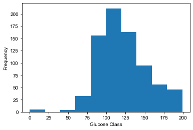

```python
plt.xlabel('Glucose Class')
dataset['Glucose'].plot.hist()
sns.set_style(style='darkgrid')
print("Mean of Glucose level is :-", dataset['Glucose'].mean())
print("Datatype of Glucose Variable is:",dataset['Glucose'].dtypes)
```

```python
#we can see there are some 0 values in Glucose, we can replace them with mean.
dataset['Glucose']=dataset['Glucose'].replace(0,dataset['Glucose'].mean())
```

```
Mean of Glucose level is :- 121.68160502115886
Datatype of Glucose Variable is: float64
```

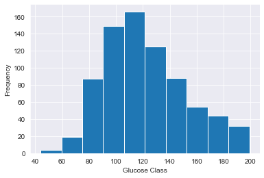

```python
#After replaceing the mean value for the Glucose
plt.xlabel('Glucose Class')
dataset['Glucose'].plot.hist()
sns.set_style(style='darkgrid')
print("Mean of Glucose level is :-", dataset['Glucose'].mean())
print("Datatype of Glucose Variable is:",dataset['Glucose'].dtypes)
```

```python
def analysis_hist(data,feature):
    plt.xlabel(feature)
    data[feature].plot.hist()
    sns.set_style(style='darkgrid')
    print("Mean of Glucose level is :-", data[feature].mean())
    print("Datatype of Glucose Variable is:",data[feature].dtypes)
```

```
Mean of Glucose level is :- 69.10546875
Datatype of Glucose Variable is: int64
```

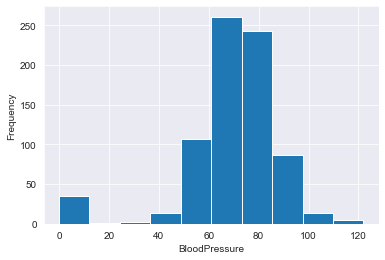

```python
# BloodPressure
analysis_hist(dataset,'BloodPressure')
```

#### I am treating missing values which is basically 0 by mean of BloodPressure level. This is because we can see from histogram most of observation have BP level between 60 and 80.

```python
#we can see there are some 0 values in BloodPressure, we can replace them with mean.
dataset['BloodPressure']=dataset['BloodPressure'].replace(0,dataset['BloodPressure'].mean())
```

```
Mean of Glucose level is :- 72.25480651855469
Datatype of Glucose Variable is: float64
```

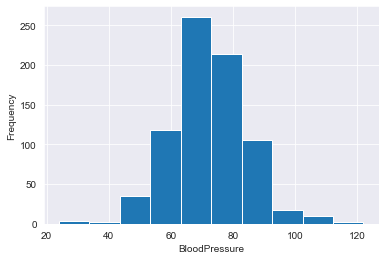

```python
#After replaceing the mean value for the BloodPressure
analysis_hist(dataset,'BloodPressure')
```

```
Mean of Glucose level is :- 20.536458333333332
Datatype of Glucose Variable is: int64
```

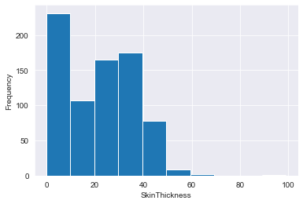

```python
# Skin Thickness
analysis_hist(dataset,'SkinThickness')
```

```python
#we can see there are some 0 values in SkinThickness, we can replace them with mean.
dataset['SkinThickness']=dataset['SkinThickness'].replace(0,dataset['SkinThickness'].mean())
```

```
Mean of Glucose level is :- 26.606479220920118
Datatype of Glucose Variable is: float64
```

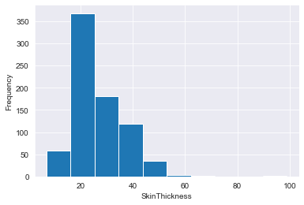

```python
#After replaceing the mean value for the Skinthickness
analysis_hist(dataset,'SkinThickness')
```

```
Mean of Glucose level is :- 79.79947916666667
Datatype of Glucose Variable is: int64
```

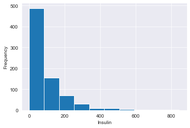

```python
# Insulin
analysis_hist(dataset,'Insulin')
```

```python
#we can see there are some 0 values in Insulin, we can replace them with mean.
dataset['Insulin']=dataset['Insulin'].replace(0,dataset['Insulin'].mean())
```

```
Mean of Glucose level is :- 118.66016303168442
Datatype of Glucose Variable is: float64
```

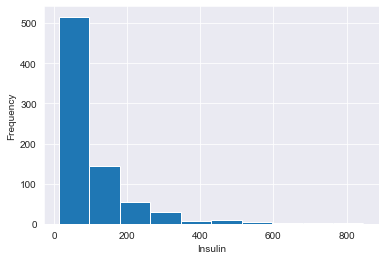

```python
#After replaceing the mean value for the Insulin
analysis_hist(dataset,'Insulin')
```

```
Mean of Glucose level is :- 31.992578124999977
Datatype of Glucose Variable is: float64
```

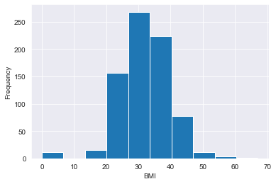

```python
#BMI(Body Mass Index)
analysis_hist(dataset,'BMI')
```

```python
#we can see there are some 0 values in Insulin, we can replace them with mean.
dataset['BMI']=dataset['BMI'].replace(0,dataset['BMI'].mean())
```

```
Mean of Glucose level is :- 32.45080515543617
Datatype of Glucose Variable is: float64
```

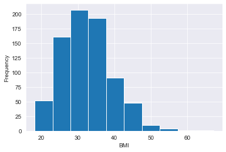

```python
#After replaceing the mean value for the BMI(Body Mass Index)
analysis_hist(dataset,'BMI')
```

```python
def plotHistogram(values,label,feature,title):
    sns.set_style("whitegrid")
    plotOne = sns.FacetGrid(values, hue=label,aspect=2)
    plotOne.map(sns.distplot,feature,kde=False)
    plotOne.set(xlim=(0, values[feature].max()))
    plotOne.add_legend()
    plotOne.set_axis_labels(feature, 'Proportion')
    plotOne.fig.suptitle(title)
    plt.show()
```

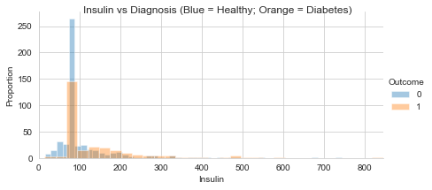

```python
plotHistogram(dataset,"Outcome",'Insulin','Insulin vs Diagnosis (Blue = Healthy; Orange = Diabetes)')
```

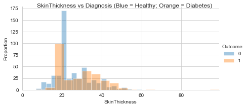

```python
plotHistogram(dataset,"Outcome",'SkinThickness','SkinThickness vs Diagnosis (Blue = Healthy; Orange = Diabetes)')
```

```python
dataset2 = dataset.iloc[:, :-1]
print("# of Rows, # of Columns: ",dataset2.shape)
print("\nColumn Name           # of Null Values\n")
print((dataset2[:] == 0).sum())
```

```
# of Rows, # of Columns:  (768, 8)

Column Name           # of Null Values

Pregnancies                 111
Glucose                       0
BloodPressure                 0
SkinThickness                 0
Insulin                       0
BMI                           0
DiabetesPedigreeFunction      0
Age                           0
dtype: int64
```

```python
print("# of Rows, # of Columns: ",dataset2.shape)
print("\nColumn Name              % Null Values\n")
print(((dataset2[:] == 0).sum())/768*100)
```

```
# of Rows, # of Columns:  (768, 8)

Column Name              % Null Values

Pregnancies                 14.453125
Glucose                      0.000000
BloodPressure                0.000000
SkinThickness                0.000000
Insulin                      0.000000
BMI                          0.000000
DiabetesPedigreeFunction     0.000000
Age                          0.000000
dtype: float64
```

## Project Task: Week 2

**Data Exploration:**

1. Check the balance of the data by plotting the count of outcomes by their value. Describe your findings and plan future course of action.
2. Create scatter charts between the pair of variables to understand the relationships. Describe your findings.
3. Perform correlation analysis. Visually explore it using a heat map.

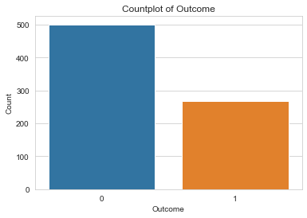

```python
#Count Plot - Week 2
#Check the balance of the data by plotting the count of outcomes by their value
sns.countplot(dataset['Outcome'])
plt.title("Countplot of Outcome")
plt.xlabel('Outcome')
plt.ylabel("Count")
```

```python
#(len(dataset.loc[dataset['Outcome'] == False]),len(dataset.loc[dataset['Outcome'] == True]))
dataset['Outcome'].value_counts()
```

```
0    500
1    268
Name: Outcome, dtype: int64
```